# Tidy Modeling in R - 3

## R Modeling Fundamentals

An example of some fundamentals for modeling in R, using data about crickets (2 species: *O.exclamationis* and *O.niveus*), and the relationship between ambient temperature and the rate of of cricket chirps per minute. Crickets data has 31 rows and 3 columns.

```r
library(tidyverse)

# install.packages("modeldata")

# load the data into environment
data(crickets, package = 'modeldata')

# column names of the crickets dataset
names(crickets)
```

```
## [1] "species" "temp"    "rate"
```

### Plot data

Plot the relationship between temperature between species and rate of cricket chirps.

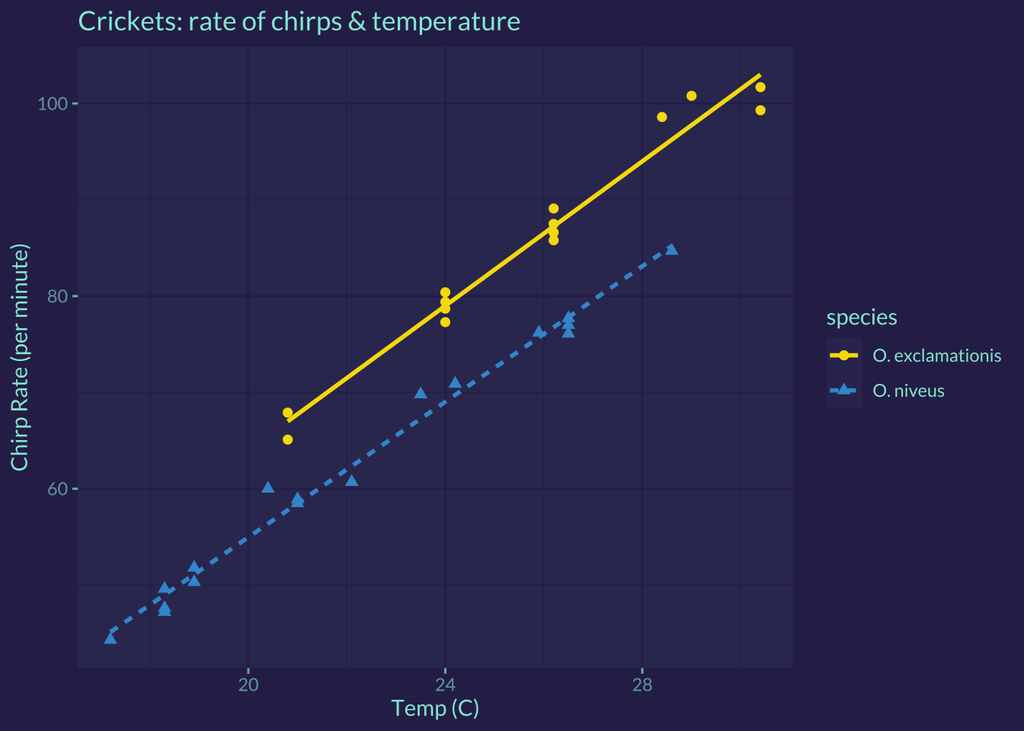

```r
library(paletteer)

ggplot(
  data = crickets,
  aes(
    x = temp,
    y = rate,
    color = species,
    pch = species,
    lty = species
  )
)+
  geom_point(size = 2)+
  # simple linear regression model, fit for each species
  geom_smooth(method= lm, formula = NULL, se= FALSE, alpha= 0.5) +
  labs(
    title = "Crickets: rate of chirps & temperature",
    x = "Temp (C)",
    y = "Chirp Rate (per minute)"
  ) +
  scale_color_paletteer_d(`"awtools::ppalette"`)
```

geom_smooth() arguments:

- method =`c('lm','glm','gam','loess')`
- formula = `y ~ x`
- `se` = display the confidence interval around smooth T/F

The linear regression shows that given temperature the *O.exclamationis* chirps more per minute than the other cricket species.

A linear regression model (`lm()`) arguments for this function are a) a dataframe and b) model formula. Formula such as `rate ~ temp` which states the chirp **rate** is the *outcome* and the **temperature** value is the *predictor*. If time were a column in the data then the formula could look like `rate ~ temp + time`, meaning that `temp` and `time` together are the predictors.

Predictors must be quantitative variables. In order for `rate ~ temp + species` to work, need to use dummy variables. Species in this data has 2 values, can be `0` = “O.exclamationis” and `1` = “O.niveus”. In order to prevent issues with the y-intercept and slope for each species, we add an *interaction term*. To expand all factors to include all possible interactions `rate ~ temp * species`.

```r
interaction_fit = lm( rate ~ (temp + species)^2, data = crickets)
interaction_fit
```

```
##
## Call:
## lm(formula = rate ~ (temp + species)^2, data = crickets)
##
## Coefficients:
##           (Intercept)                   temp       speciesO. niveus
##               -11.041                  3.751                 -4.348
## temp:speciesO. niveus
##                -0.234
```

**residual** is the vertical distance from the line of best fit a data point is

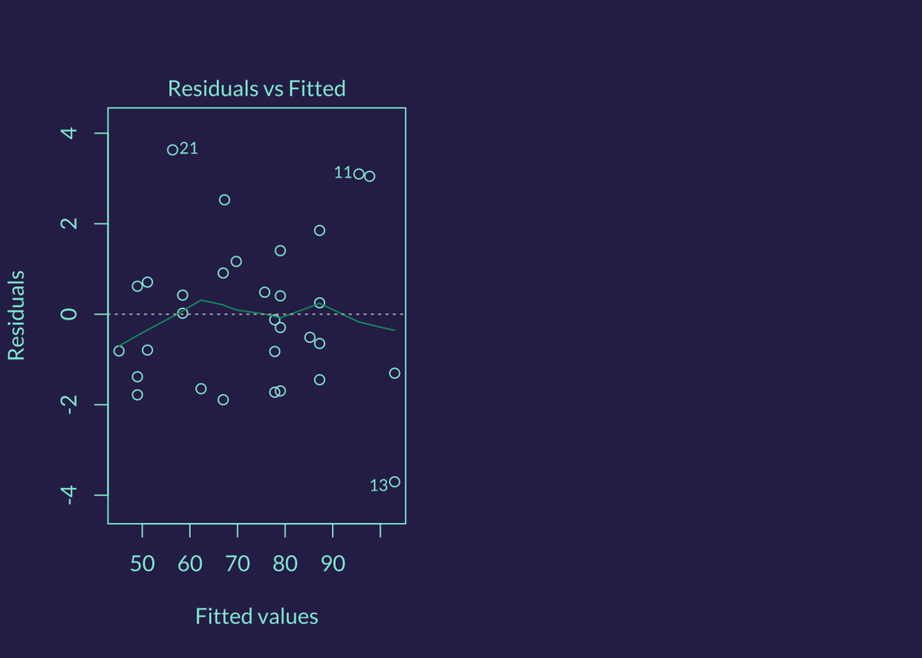

```r
# Have 2 plots next to each other
par(mfrow = c(1, 2))

# show residuals vs predicted values
plot(interaction_fit, which = 1)
```

Assess if the inclusion of the interaction term in necessary, using the `anova()` method.

```r
formula = rate ~ temp + species

main_effect_fit = lm(formula, data = crickets)

# compare the 2
anova(main_effect_fit, interaction_fit)
```

```
## Analysis of Variance Table
##
## Model 1: rate ~ temp + species
## Model 2: rate ~ (temp + species)^2
##   Res.Df    RSS Df Sum of Sq     F Pr(>F)
## 1     28 89.350
## 2     27 85.074  1    4.2758 1.357 0.2542
```

The p-value is 0.25, which implies that there is a lack of evidence against null hypothesis, the interaction term is not needed by the model.

Residual plots should be re-assessed to make sure that our theoretical assumptions are valid enough to trust the p-values produced by the model.

Use the `summary()` function to inspect the model

```r
summary(main_effect_fit)
```

```
##
## Call:
## lm(formula = formula, data = crickets)
##
## Residuals:
##     Min      1Q  Median      3Q     Max
## -3.0128 -1.1296 -0.3912  0.9650  3.7800
##
## Coefficients:
##                   Estimate Std. Error t value Pr(>|t|)
## (Intercept)       -7.21091    2.55094  -2.827  0.00858 **
## temp               3.60275    0.09729  37.032  < 2e-16 ***
## speciesO. niveus -10.06529    0.73526 -13.689 6.27e-14 ***
## ---
## Signif. codes:  0 '***' 0.001 '**' 0.01 '*' 0.05 '.' 0.1 ' ' 1
##
## Residual standard error: 1.786 on 28 degrees of freedom
## Multiple R-squared:  0.9896, Adjusted R-squared:  0.9888
## F-statistic:  1331 on 2 and 28 DF,  p-value: < 2.2e-16
```

If we needed to estimate the chirp rate at a temperature that was not observed in the experiment, we could use the predict() method.

Let’s predict the chirp rate for *O.exclamationis* for temperatures between 15 C and 20 C.

```r
new_values = data.frame(
  species = "O. exclamationis",
  temp = 15:20
)

predict(main_effect_fit, newdata = new_values)
```

```
##        1        2        3        4        5        6
## 46.83039 50.43314 54.03589 57.63865 61.24140 64.84415
```

## Tidy Models format

Tidy Model format style 2 ways of plotting data

```
plot(plot_data$x , plot_data$y)

# 1
library(lattice)
xyplot( y ~ x, data= plot_data)

# 2
library(ggplot2)
ggplot(plot_data, aes(x= x, y= y)) + geom_point()
```

If modeling has an outcome with 2 classes, there are a variety of models to use, and to use `predict()`

### modeling functions

| function | Pkg | Code |
| --- | --- | --- |
| `lda()` | MASS | predict(object) |
| `glm()` | stats | predict(object, type=‘response’) |
| `gbm()` | gbm | predict(object, type = “response”, n.trees) |
| `mda()` | mda | predict(object, type = “posterior”) |
| `rpart()` | rpart | predict(object, type = “prob”) |
| various | RWeka | predict(object, type = “probability”) |
| `logitboost()` | LogitBoost | predict(object, type = “raw”, nIter) |
| `pamr.train()` | pamr | pamr.predict(object, type = “posterior”) |

### Handle missing values

Data that has missing values will cause errors when making predictions

```r
# add missing value
new_values$temp[1] = NA

# simply omit the missing value, now 5 rows NOT 6
predict(main_effect_fit, newdata = new_values, na.action = na.omit)
```

```
##        2        3        4        5        6
## 50.43314 54.03589 57.63865 61.24140 64.84415
```

### Correlation example

In an example of predictors being used to screen basedon their correlation to the outcome column.

```r
corr_res = map(mtcars %>% select(-mpg), cor.test, y= mtcars$mpg)

corr_res[[1]]
```

```
##
##  Pearson's product-moment correlation
##
## data:  .x[[i]] and mtcars$mpg
## t = -8.9197, df = 30, p-value = 6.113e-10
## alternative hypothesis: true correlation is not equal to 0
## 95 percent confidence interval:
##  -0.9257694 -0.7163171
## sample estimates:
##       cor
## -0.852162
```

```r
# use the broom library to return a tibble
library(broom)

tidy( corr_res[[1]] )
```

```
## # A tibble: 1 × 8
##   estimate statistic  p.value parameter conf.low conf.high method    alternative
##      <dbl>     <dbl>    <dbl>     <int>    <dbl>     <dbl> <chr>     <chr>
## 1   -0.852     -8.92 6.11e-10        30   -0.926    -0.716 Pearson'… two.sided
```

Plot it

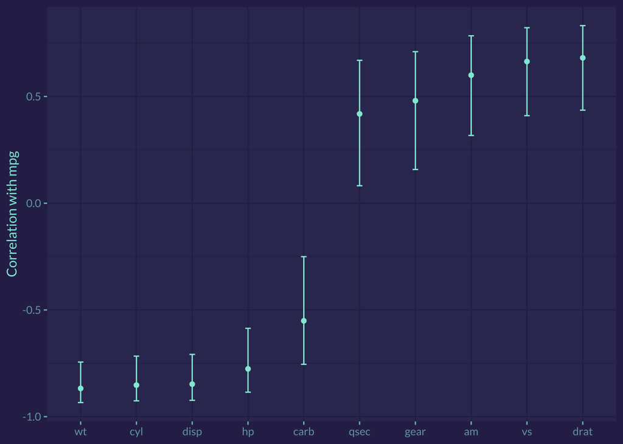

```r
corr_res %>%
  # map to a tidy dataframe
  map_dfr(tidy, .id = 'predictor') %>%
  ggplot( aes(x = fct_reorder(predictor, estimate))) +
  geom_point( aes(y= estimate))+
  geom_errorbar(aes(ymin = conf.low, ymax = conf.high), width = .1) +
  labs(x = NULL, y = "Correlation with mpg")
```

### Split data

```r
split_by_species = crickets %>%
  group_nest(species)

# data column has the `rate` and `temp` columns
split_by_species
```

```
## # A tibble: 2 × 2
##   species                        data
##   <fct>            <list<tibble[,2]>>
## 1 O. exclamationis           [14 × 2]
## 2 O. niveus                  [17 × 2]
```

### Model by species

```r
# purrr::map()
model_by_species =
  split_by_species %>%
  mutate(model = map(data, ~ lm(rate ~ temp, data = .x)))

model_by_species %>%
  mutate(coef = map(model, tidy)) %>%
  select(species, coef) %>%
  unnest(cols = c(coef))
```

```
## # A tibble: 4 × 6
##   species          term        estimate std.error statistic  p.value
##   <fct>            <chr>          <dbl>     <dbl>     <dbl>    <dbl>
## 1 O. exclamationis (Intercept)   -11.0      4.77      -2.32 3.90e- 2
## 2 O. exclamationis temp            3.75     0.184     20.4  1.10e-10
## 3 O. niveus        (Intercept)   -15.4      2.35      -6.56 9.07e- 6
## 4 O. niveus        temp            3.52     0.105     33.6  1.57e-15
```